# Homework

Fengrong Liu SA20229004

2020-12-21

# HW0 (2020.09.22)

## Question

Use knitr to produce 3 examples in the book.  
The 1st example should contain texts and at least one figure.  
The 2nd example should contain texts and at least one table.  
The 3rd example should contain at least a couple of LaTeX formulas.

## Answer

### 1. The 1st example.

Boxplot, also called Box-whisker Plot, is a method using five statistics in the data (minimum, first quartile, median, third quartile and maximum) to describe data. It can also roughly see whether the data has symmetry, the degree of dispersion and other information, especially for the comparison of several samples. The figure below shows the box plot of InsectSprays data set (The counts of insects in agricultural experimental units treated with different insecticides).

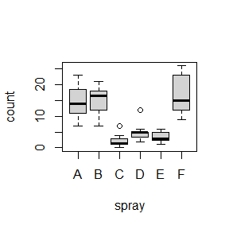

```r
boxplot(count ~ spray, data = InsectSprays, col = "lightgray")
```

### 2. The 2nd example.

The mtcars data set is extracted from the 1974 *Motor Trend* US magazine, and comprises fuel consumption and 10 aspects of automobile design and performance for 32 automobiles (1973–74 models). The following table shows all the information of this data set.

```r
library(DT)
datatable(mtcars)
```

|  | mpg | cyl | disp | hp | drat | wt | qsec | vs | am | gear | carb |
| --- | --- | --- | --- | --- | --- | --- | --- | --- | --- | --- | --- |
| Mazda RX4 | 21 | 6 | 160 | 110 | 3.9 | 2.62 | 16.46 | 0 | 1 | 4 | 4 |
| Mazda RX4 Wag | 21 | 6 | 160 | 110 | 3.9 | 2.875 | 17.02 | 0 | 1 | 4 | 4 |
| Datsun 710 | 22.8 | 4 | 108 | 93 | 3.85 | 2.32 | 18.61 | 1 | 1 | 4 | 1 |
| Hornet 4 Drive | 21.4 | 6 | 258 | 110 | 3.08 | 3.215 | 19.44 | 1 | 0 | 3 | 1 |
| Hornet Sportabout | 18.7 | 8 | 360 | 175 | 3.15 | 3.44 | 17.02 | 0 | 0 | 3 | 2 |
| Valiant | 18.1 | 6 | 225 | 105 | 2.76 | 3.46 | 20.22 | 1 | 0 | 3 | 1 |
| Duster 360 | 14.3 | 8 | 360 | 245 | 3.21 | 3.57 | 15.84 | 0 | 0 | 3 | 4 |
| Merc 240D | 24.4 | 4 | 146.7 | 62 | 3.69 | 3.19 | 20 | 1 | 0 | 4 | 2 |
| Merc 230 | 22.8 | 4 | 140.8 | 95 | 3.92 | 3.15 | 22.9 | 1 | 0 | 4 | 2 |
| Merc 280 | 19.2 | 6 | 167.6 | 123 | 3.92 | 3.44 | 18.3 | 1 | 0 | 4 | 4 |

[output cut: 22 more lines]

### 3. The 3rd example.

For multiple linear regression models:
$$Y=\beta_{0}+\beta_{1}X_{1}+\cdots+\beta_{p-1}X_{p-1}+e \tag{1}$$
where $E(e)=0$. Supposing we make $n$ times observations of $Y,X_{1},\dots,X_{p-1}$. The most commonly used hypothesis about $e$ is the Gauss-Markov hypothesis, namely:
(1)$~~Var(e_{i})=\sigma^{2}, ~~~~~~~~~~i=1,2,\dots,n$
(2)$~~Cov(e_{i},e_{j})=0, ~~~~~~~i \ne j, ~~~~i,j=1,2,\dots,n$

# HW1 (2020.09.29)

## Question

### Q1(3.3)

The Pareto(a, b) distribution has cdf

$$F(x)=1-(\frac{b}{x})^a, ~~~~ x \ge b >0,a>0.$$

Derive the probability inverse transformation $F^{-1}(U)$ and use the inverse transform method to simulate a random sample from the Pareto(2,2) distribution. Graph the density histogram of the sample with the Pareto(2,2) density superimposed for comparison.

### Q2(3.9)

The rescaled Epanechnikov kernel [85] is a symmetric density function

$$\begin{equation}
f_{e}(x)=\frac{3}{4}(1-x^2), ~~~~ \left\vert x \right\vert \le 1. \tag{3.10}
\end{equation}$$

Devroye and Györfi [71, p.236] give the following algorithm for simulation from this distribution. Generate iid $U_{1}, U_{2}, U_{3} \sim$ Uniform(−1, 1). If $\left\vert U_{3} \right\vert \ge \left\vert U_{2} \right\vert$ and $\left\vert U_{3} \right\vert \ge \left\vert U_{1} \right\vert$, deliver $U_{2}$; otherwise deliver $U_{3}$. Write a function to generate random variates from $f_{e}$, and construct the histogram density estimate of a large simulated random sample.

### Q3(3.10)

Prove that the algorithm given in Exercise 3.9 generates variates from the density $f_{e}$ (3.10).

### Q4(3.13)

It can be shown that the mixture in Exercise 3.12 has a Pareto distribution with cdf
$$F(y)=1-(\frac{\beta}{\beta+y})^r, ~~~~ y \ge 0.$$
(This is an alternative parameterization of the Pareto cdf given in Exercise 3.3.) Generate 1000 random observations from the mixture with $r$ = 4 and $\beta$ = 2. Compare the empirical and theoretical (Pareto) distributions by graphing the density histogram of the sample and superimposing the Pareto density curve.

## Answer

### A1(3.3)

:
$$\begin{eqnarray*}
F(x)=1-(\frac{b}{x})^a=u &\Rightarrow& (\frac{b}{x})^a=1-u \\
&\Rightarrow& a\ln (\frac{b}{x})=\ln (1-u) \\
&\Rightarrow& a\ln b - a\ln x=\ln (1-u) \\
&\Rightarrow& \ln x=\ln b - \frac{1}{a} \ln (1-u) \\
&\Rightarrow& x=\frac{b}{{}^a\!\sqrt{1-u}} \\
\therefore F^{-1}(u)=\frac{b}{{}^a\!\sqrt{1-u}}
\end{eqnarray*}$$

$$\begin{eqnarray*}
f(x)=F^\prime(x)=-a(\frac{b}{x})^{a-1} \cdot (-\frac{b}{x^2})=\frac{ab^a}{x^(a+1)}
\end{eqnarray*}$$

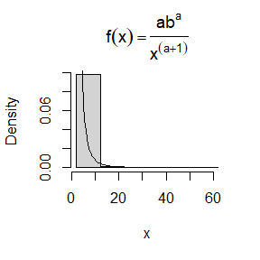

```r
set.seed(100000)
a <- 2
b <- 2
n <- 1000
u <- runif(n)
x <- b/((1-u)^(1/a))
hist(x,prob=T,breaks = seq(2,ceiling(max(x)/10)*10+2,by=10),main=expression(f(x)==frac(ab^a,x^(a+1))))
y <- seq(2,max(x),length=100)
lines(y,a*(b^a)/(y^(a+1)))
```

As shown in the figure above, there is the histogram of the sample and the black line is the probability density curve of Pareto(2,2).

### A2(3.9)

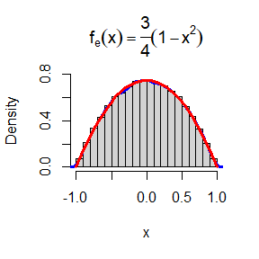

```r
f1 <- function(n){
  u1 <- runif(n, min=-1, max=1)
  u2 <- runif(n, min=-1, max=1)
  u3 <- runif(n, min=-1, max=1)
  u <- numeric()
  for(i in 1:n)
    if(abs(u3[i])>=max(abs(u2[i]),abs(u1[i]))) u[i] <- u2[i] else u[i] <- u3[i]
  return(u)
}
n <- 100000
x <- f1(n)
hist(x,pro=T,ylim=c(0,0.8),main=expression(f[e](x)==frac(3,4)(1-x^2)))
lines(density(x,kernel="epanechnikov"),col="blue",lwd=3)
y <- seq(-1,1,by=0.05)
lines(y,3/4*(1-y^2),col="red",lwd=3)
```

As shown in the figure above is the histogram of the sample. The blue line is the histogram density estimate of simulated random sample of size 100,000 using Epanechnikov kernel and the red line is the true probability density curve of $f_{e}$.

### A3(3.10)

:

$$\begin{eqnarray*}
f_{e}=\frac{3}{4}(1-x^2) \Rightarrow F(x) &=& \int_{-1}^{x} \frac{3}{4}(1-t^2)\, \mathrm{d}t \\
&=& \left.{\frac{3}{4}(t-\frac{1}{3}t^3)}\vphantom{\Big|}\right|_{-1}^{x} \\
&=& -\frac{1}{4}x^3+\frac{3}{4}x+\frac{1}{2}
\end{eqnarray*}$$

由题意可知：$U_{1},U_{2},U_{3} \stackrel{i.i.d}{\sim} U(-1,1), ~~~~ \left\vert U_{1} \right\vert,\left\vert U_{2} \right\vert,\left\vert U_{3} \right\vert \stackrel{i.i.d}{\sim} U(0,1)$

$P(U \le x)=P(U_{2} \le x, \left\vert U_{3} \right\vert \ge \left\vert U_{2} \right\vert, \left\vert U_{3} \right\vert \ge \left\vert U_{1} \right\vert)+P(U_{3} \le x, \left\vert U_{3} \right\vert < \left\vert U_{2} \right\vert 或 \left\vert U_{3} \right\vert < \left\vert U_{1} \right\vert)$

$\because \left\vert U_{1} \right\vert,\left\vert U_{3} \right\vert,U_{2}$相互独立

$\therefore f(\left\vert U_{1} \right\vert,\left\vert U_{3} \right\vert,U_{2})=f(\left\vert U_{1} \right\vert)f(\left\vert U_{3} \right\vert)f(U_{2})=1 \cdot 1 \cdot \frac{1}{2}=\frac{1}{2}$

$$\begin{eqnarray*}
P(U_{2} \le x, \left\vert U_{3} \right\vert \ge \left\vert U_{2} \right\vert, \left\vert U_{3} \right\vert \ge \left\vert U_{1} \right\vert) &=& \int_{-1}^{x}\int_{\left\vert U_{2} \right\vert}^{2}\int_{0}^{\left\vert U_{3} \right\vert} \frac{1}{2}\, \mathrm{d}{\left\vert U_{1} \right\vert}\mathrm{d}{\left\vert U_{3} \right\vert}\mathrm{d}U_{2}
= \int_{-1}^{x}\int_{\left\vert U_{2} \right\vert}^{2} \frac{1}{2}\left\vert U_{3} \right\vert\, \mathrm{d}{\left\vert U_{3} \right\vert}\mathrm{d}U_{2}
= \int_{-1}^{x} \frac{1}{4}(1-\left\vert U_{2} \right\vert ^2)\, \mathrm{d}U_{2} \\
&=& \int_{-1}^{x} \frac{1}{4}(1-U_{2}^2)\, \mathrm{d}U_{2}
= \left.{\frac{1}{4}(U_{2}-\frac{1}{3}U_{2}^3)}\vphantom{\Big|}\right|_{-1}^{x}
= -\frac{1}{12}x^3+\frac{1}{4}x+\frac{1}{6}
\end{eqnarray*}$$

令$T=\max(\left\vert U_{1} \right\vert,\left\vert U_{2} \right\vert)$,则对于$0 \le t \le 1$有

$F_{2}(t)=P(T \le t)=P(\max(\left\vert U_{1} \right\vert,\left\vert U_{2} \right\vert) \le t)=P(\left\vert U_{1} \right\vert \le t,\left\vert U_{2} \right\vert \le t)=P(\left\vert U_{1} \right\vert \le t)P(\left\vert U_{2} \right\vert \le t)=t^2 \Rightarrow f(t)=2t$

$$\begin{eqnarray*}
P(U_{3} \le x, \left\vert U_{3} \right\vert < \left\vert U_{2} \right\vert 或 \left\vert U_{3} \right\vert < \left\vert U_{1} \right\vert)
&=& P(U_{3} \le x,\left\vert U_{3} \right\vert < \max(\left\vert U_{1} \right\vert,\left\vert U_{2} \right\vert))
=P(U_{3} \le x,\left\vert U_{3} \right\vert < T) \\
&=& P(U_{3} \le x,-T<U_{3}<T)
=P(U_{3} \le x,-T \le U_{3} \le T)
\end{eqnarray*}$$

$U_{3},\left\vert U_{1} \right\vert,\left\vert U_{2} \right\vert相互独立 \Rightarrow U_{3}与T相互独立 \Rightarrow f(U_{3},T)=f(U_{3})f(T)=\frac{1}{2} \cdot 2T=T$

$(1) ~~0 \le x \le 1$时

$$\begin{eqnarray*}
P(U_{3} \le x, -T \le U_{3} \le T)
&=& P(-T \le U_{3} \le \min(X,T)) = P(-T \le U_{3} \le x,0 \le x \le T \le 1)+P(-T \le U_{3} \le T, 0 \le T \le x \le 1) \\
&=& \int_{x}^{1}\int_{-T}^{x} T\, \mathrm{d}U_{3}\mathrm{d}T+\int_{0}^{x}\int_{-T}^{T} T\, \mathrm{d}U_{3}\mathrm{d}T
= -\frac{1}{6}x^3+\frac{1}{2}x+\frac{1}{3}
\end{eqnarray*}$$

$(2) ~~-1 \le x \le 0$时

$P(U_{3} \le x, -T \le U_{3} \le T) = P(-T \le U_{3} \le x, -T \le x) = \int_{-x}^{1}\int_{-T}^{x} T\, \mathrm{d}U_{3}\mathrm{d}T = -\frac{1}{6}x^3+\frac{1}{2}x+\frac{1}{3}$

$\therefore 对-1 \le x \le 1，都有P(U_{3} \le x, -T \le U_{3} \le T) = -\frac{1}{6}x^3+\frac{1}{2}x+\frac{1}{3}$

$$\begin{eqnarray*}
\therefore P(U \le x) &=& P(U_{2} \le x, \left\vert U_{3} \right\vert \ge \left\vert U_{2} \right\vert, \left\vert U_{3} \right\vert \ge \left\vert U_{1} \right\vert)+P(U_{3} \le x, \left\vert U_{3} \right\vert < \left\vert U_{2} \right\vert 或 \left\vert U_{3} \right\vert < \left\vert U_{1} \right\vert) \\
&=& -\frac{1}{12}x^3+\frac{1}{4}x+\frac{1}{6} + -\frac{1}{6}x^3+\frac{1}{2}x+\frac{1}{3} \\
&=& -\frac{1}{4}x^3+\frac{3}{4}x+\frac{1}{2}=F(x)
\end{eqnarray*}$$

$\therefore U \sim f_{e}=\frac{3}{4}(1-x^2),~~~ \left\vert x \right\vert \le 1$

### A4(3.13)

$F(y)=1-\frac{\beta}{\beta+y}^r, ~~~~~ y \ge 0$  
$\Rightarrow f(y)=-r(\frac{\beta}{\beta+y})^{r-1} \cdot \frac{-\beta}{(\beta+y)^2}=\frac{r \beta^r}{(\beta+y)^{r+1}}$

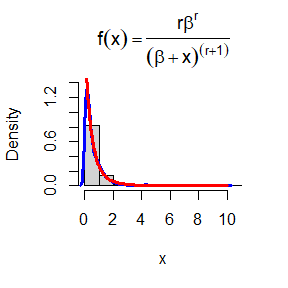

```r
set.seed(100000)
n <- 1000
r <- 4
beta <- 2
lambda <- rgamma(n,r,beta)
x <- rexp(n,lambda)
hist(x,pro=T,ylim=c(0,1.4),main=expression(f(x)==frac(r*beta^r,(beta+x)^(r+1))))
lines(density(x,kernel="gaussian"),col="blue",lwd=3)
y <- seq(0,max(x),length=100)
lines(y,r*beta^r/(beta+y)^(r+1),col="red",lwd=3)
```

As shown in the figure above is the density histogram of the sample. The blue line is the histogram density estimate of simulated random sample of size 1,000 using Gaussian kernel ,and the red line is the true probability density curve of theoretical Pareto distribution.

# HW2 (2020.10.13)

## Question

### Q1(5.1)

Compute a Monte Carlo estimate of

$$\int_{0}^{\pi/3}\, \sin t\, dt$$

and compare your estimate with the exact value of the integral.

### Q2(5.7)

Refer to Exercise 5.6. Use a Monte Carlo simulation to estimate $\theta$ by the antithetic variate approach and by the simple Monte Carlo method. Compute an empirical estimate of the percent reduction in variance using the antithetic variate. Compare the result with the theoretical value from Exercise 5.6.

### Q3(5.11)

If $\hat{\theta}_{1}$ and $\hat{\theta}_{2}$ are unbiased estimators of $\theta$, and $\hat{\theta}_{1}$ and $\hat{\theta}_{2}$ are antithetic, we derived that $c^{*}=1/2$ is the optimal constant that minimizes the variance of $\hat{\theta}_{c}=c\hat{\theta}_{1}+(1-c)\hat{\theta}_{2}$. Derive $c^{*}$ for the general case. That is, if $\hat{\theta}_{1}$ and $\hat{\theta}_{2}$ are any two unbiased estimators of $\theta$, find the value $c^{*}$ that minimizes the variance of the estimator $\hat{\theta}_{c}=c\hat{\theta}_{1}+(1-c)\hat{\theta}_{2}$ in equation (5.11). ($c^{*}$ will be a function of the variances and the covariance of the estimators.)

## Answer

### A1(5.1)

$\int_{0}^{\pi/3}\, \sin t\, dt=\int_{0}^{\pi/3}\, \frac{\pi}{3}\sin t \cdot \frac{1}{\pi/3}\, dt= \frac{\pi}{3}E(\sin t),~~t\sim U(0,\frac{\pi}{3})$

$\int_{0}^{\pi/3}\, \sin t\, dt=1-\cos\frac{\pi}{3}=0.5$

```r
set.seed(12345)
ns = 10000
u = runif(ns,0,pi/3)
estimator = (pi/3)*mean(sin(u))
exact = 0.5
print(c(estimator, exact, estimator-exact))
```

```
## [1] 0.5009124283 0.5000000000 0.0009124283
```

According to the result, we can see that the difference between exact value and estimated value from Monte Carlo iteration with sample size of 10,000 is very small.

### A2(5.7)

1. For simple Monte Carlo simulation

$\theta_{1}=\frac{1}{m}\sum_{i=1}^{m}e^{X_{i}}$  
$Var(\theta_{1})=\frac{1}{m^2}\sum_{i=1}^{m}Var(e^{X_{i}})=\frac{1}{m}Var(e^{X_{1}})$  
$Var(e^{X_{1}})=E(e^{2X})-[E(e^{X})]^2=\int_{0}^{1}e^{2x}\mathrm{d}x-(\int_{0}^{1}e^{x}\mathrm{d}x)^2=\frac{1}{2}(-e^2+4e-3)$  
$\Rightarrow Var(\theta_{1})=\frac{1}{2m}(-e^2+4e-3)$

2. For antithetic variate approach

$\theta_{2}=\frac{1}{m}\sum_{i=1}^{m/2}(e^{X_{i}}+e^{1-X_{i}})$  
$Var(\theta_{2})=\frac{1}{m^2}\sum_{i=1}^{m/2}Var(e^{X_{i}}+e^{1-X_{i}})=\frac{1}{2m}Var(e^{X_{1}}+e^{1-X_{1}})=\frac{1}{2m}[Var(e^{X_{1}})+Var(e^{1-X_{1}})+2Cov(e^{X_{1}},e^{1-X_{1}})]$  
$Var(e^{1-X_{1}})=E(e^{2-2X})-[E(e^{1-X})]^2=\int_{0}^{1}e^{2-2x}\mathrm{d}x-(\int_{0}^{1}e^{1-x}\mathrm{d}x)^2=\frac{1}{2}(-e^2+4e-3)=Var(e^{X})$  
$Cov(e^{X_{1}},e^{1-X_{1}})=E(e^{X} \cdot e^{1-X})-E(e^{X})E(e^{1-X})=e-(e-1)^2=-e^2+3e-1$  
$\Rightarrow Var(\theta_{2})=\frac{1}{2m}(-3e^2+10e-5)$

$\therefore \frac{Var(\theta_{1})-Var(\theta_{2})}{Var(\theta_{1})}=\frac{2e^2-6e+2}{-e^2+4e-3}$

```r
set.seed(12345)
ns = 10000
nm = 1000
theta1 = theta2 = numeric(nm)
for(ii in 1:nm){
  u1 = runif(ns,0,1)
  u2 = runif(ns/2,0,1)
  theta1[ii] = mean(exp(u1)) # simple Monte Carlo
  theta2[ii] = mean(exp(u2)+exp(1-u2))/2 # antithetic variate approach
}
var1 = var(theta1)
var2 = var(theta2)
p_estimated = (var1-var2)/var1
p_thero = 2*(exp(2)-3*exp(1)+1)/(-exp(2)+4*exp(1)-3)
print(c(p_estimated,p_thero))
```

```
## [1] 0.9677987 0.9676701
```

According to the result, we can see that the difference between the empirical estimate of the percent reduction in variance using the antithetic variate and theoretical value is very small.

### A3(5.11)

$\forall ~~ \hat{\theta}_{1},\hat{\theta}_{2},E(\hat{\theta}_{1})=E(\hat{\theta}_{2})=\theta$  
Set $\hat{\theta}_{c}=c\hat{\theta}_{1}+(1-c)\hat{\theta}_{2}=c(\hat{\theta}_{1}-\hat{\theta}_{2})+\hat{\theta}_{2}$

$$\begin{eqnarray*}
Var(\hat{\theta}_{c})
&=& c^2Var(\hat{\theta}_{1}-\hat{\theta}_{2})+2cCov(\hat{\theta}_{2},\hat{\theta}_{1}-\hat{\theta}_{2})+Var(\hat{\theta}_{2}) \\
&=& (c \cdot sd(\hat{\theta}_{1}-\hat{\theta}_{2}))^2+2c \cdot sd(\hat{\theta}_{1}-\hat{\theta}_{2}) \cdot \frac{Cov(\hat{\theta}_{2},\hat{\theta}_{1}-\hat{\theta}_{2})}{sd(\hat{\theta}_{1}-\hat{\theta}_{2})}+\frac{Cov^2(\hat{\theta}_{2},\hat{\theta}_{1}-\hat{\theta}_{2})}{Var(\hat{\theta}_{1}-\hat{\theta}_{2})}-\frac{Cov^2(\hat{\theta}_{2},\hat{\theta}_{1}-\hat{\theta}_{2})}{Var(\hat{\theta}_{1}-\hat{\theta}_{2})}+Var(\hat{\theta}_{2}) \\
&=& (c \cdot sd(\hat{\theta}_{1}-\hat{\theta}_{2})+\frac{Cov(\hat{\theta}_{2},\hat{\theta}_{1}-\hat{\theta}_{2})}{sd(\hat{\theta}_{1}-\hat{\theta}_{2})})^2+Var(\hat{\theta}_{2})-\frac{Cov^2(\hat{\theta}_{2},\hat{\theta}_{1}-\hat{\theta}_{2})}{Var(\hat{\theta}_{1}-\hat{\theta}_{2})}
\end{eqnarray*}$$

$\because \frac{Cov^2(\hat{\theta}_{2},\hat{\theta}_{1}-\hat{\theta}_{2})}{Var(\hat{\theta}_{1}-\hat{\theta}_{2})} \ge 0$  
When $c \cdot sd(\hat{\theta}_{1}-\hat{\theta}_{2})+\frac{Cov(\hat{\theta}_{2},\hat{\theta}_{1}-\hat{\theta}_{2})}{sd(\hat{\theta}_{1}-\hat{\theta}_{2})}=0 \iff c=-\frac{Cov(\hat{\theta}_{2},\hat{\theta}_{1}-\hat{\theta}_{2})}{Var(\hat{\theta}_{1}-\hat{\theta}_{2})}, ~~~ Var(\hat{\theta}_{c})$ reaches its minimum value.  
$\therefore c^{*}=-\frac{Cov(\hat{\theta}_{2},\hat{\theta}_{1}-\hat{\theta}_{2})}{Var(\hat{\theta}_{1}-\hat{\theta}_{2})}$

# HW3 (2020.10.20)

## Question

5.13. Find two importance functions $f_{1}$ and $f_{2}$ that are supported on $(1,\infty)$ and are ‘close’ to
$$g(x)=\frac{x^2}{\sqrt{2\pi}}e^{-x^2/2}, ~~~~~x>1.$$
Which of your two importance functions should produce the smaller variance in estimating
$$\int_{1}^{\infty}\,\frac{x^2}{\sqrt{2\pi}}e^{-x^2/2}\, \mathrm{d}x$$
by importance sampling? Explain.

## Answer

We can set $f_{1}(x)=xe^{-\frac{x^2-1}{2}}$ and $f_{2}(x)=e^{-x+1}.$  
Therefore, $\int_{1}^{\infty}\, xe^{-\frac{x^2-1}{2}}\, \mathrm{d}x=\left.{-e^{\frac{1}{2}}e^{-\frac{x^2}{2}}}\vphantom{\Big|}\right|_{1}^{\infty}=1$ and $\int_{1}^{\infty}\, e^{-x+1}\, \mathrm{d}x\left.{-e^{-x+1}}\vphantom{\Big|}\right|_{1}^{\infty}=1.$  
$F_1(x)=\int_{1}^{x}\, te^{-\frac{t^2-1}{2}}\, \mathrm{d}t=1-e^{-\frac{x^2-1}{2}},~~F_2(x)=\int_{1}^{x}\, e^{-t+1}\, \mathrm{d}t=1-e^{-x+1}.$  
$x_1=\sqrt{-2ln(1-u)+1},~~x_2=1-ln(1-u).$  
$g(x)/f_{1}(x)=c_{1}x,~~g(x)/f_{2}(x)=c_{2}x^2e^{-\frac{x^2-2x}{2}}$, where $c_{1}$ and $c_{2}$ are constant and $c_{1} \ne 0,~c_{2} \ne 0.$

```r
set.seed(12345)
M <- 1e4
g <- function(x) x^2*exp(-x^2/2)/sqrt(2*pi)*(x>1)
theta.hat <- se <- numeric(2)

u <- runif(M)
x1 <- sqrt(-2*log(1-u)+1)
fg1 <- g(x1)/(x1*exp(-(x1^2-1)/2))*(x1>1)
theta.hat[1]<- mean(fg1)
se[1] <- sd(fg1)

x2 <- 1-log(1-u)
fg2 <- g(x2)/exp(-x2+1)*(x2>1)
theta.hat[2]<- mean(fg2)
se[2] <- sd(fg2)

matrix(c(theta.hat,se), nrow = 2, dimnames = list(c("f1","f2"),c("theta.hat","se")))
```

```
##    theta.hat        se
## f1 0.4004062 0.1220216
## f2 0.4027508 0.1565379
```

## Question

5.15. Obtain the stratified importance sampling estimate in Example 5.13 and compare it with the result of Example 5.10.

## Answer

$g(x)=\int_{0}^{1}\, \frac{e^{-x}}{1+x^2} \mathrm{d}x,~~f(x)=\frac{e^{-x}}{1-e^{-1}}$  
for $j=1,\cdots,5$  
$f_{j}(x)=\frac{f(x)}{P(\frac{j-1}{5}<x\le \frac{j}{5})}=\frac{e^{-x}/(1-e^{-1})}{\int_{(j-1)/5}^{j/5}\,\frac{e^{-x}}{1-e^{-1}}\,\mathrm{d}x}=\frac{e^{-x}}{e^{-(j-1)/5}-e^{-j/5}}$  
$\theta_{j}=\int_{\frac{j-1}{5}}^{\frac{j}{5}}\, \frac{g(x)}{f_{j}(x)}f_{j}(x)\,\mathrm{d}x$  
$\Rightarrow\hat{\theta}_{SI}=\sum_{j=1}^{5} \hat{\theta}_{j},~~~Var(\hat{\theta}_{SI})=Var(\sum_{j=1}^{5} \hat{\theta}_{j})=\sum_{j=1}^{5} Var(\hat{\theta}_{j}).$

```r
set.seed(12345)
M <- 10000
k <- 5 # the number of stratum
r <- M/k # repetitions in each stratum
N <- 50 # the number of times to repeat the estimation
estimator <- matrix(nrow=N, ncol=k)
f1 <- function(x,j) (exp(-(j-1)/k)-exp(-j/k))/(1+x^2)*(x>(j-1)/k)*(x<j/k)
for(i in 1:N)
  for(j in 1:k)
    estimator[i,j] <- mean(f1(runif(r,(j-1)/k,j/k),j))
est <- sum(apply(estimator,2,mean))
est.var <- sum(apply(estimator,2,var))/r
est.sd <- sqrt(est.var)
est.sd1 <- 0.09658794/sqrt(M)
print(c(0.52506988, est))
```

```
## [1] 0.5250699 0.5238015
```

```r
print(c(est.sd1, est.sd))
```

```
## [1] 9.658794e-04 3.924391e-06
```

Compared to the result of Example 5.10, we can see that stratified importance sampling estimate is similar to importance sampling estimate, but its standard error is much less than the standard error of importance sampling estimate.

## Question

6.4. Suppose that $X_{1},\dots,X_{n}$ are a random sample from a from a lognormal distribution with unknown parameters. Construct a 95% confidence interval for the parameter $\mu$. Use a Monte Carlo method to obtain an empirical estimate of the confidence level.

## Answer

$lnX \sim N(\mu,\sigma^2)$  
$\Rightarrow$ for sample $X_{1},\dots,X_{n}$, $lnX_{1},\dots,lnX_{n} \stackrel{i.i.d}{\sim} N(\mu,\sigma^2)$  
$\frac{1}{n}\sum_{i=1}^{n}lnX_{i} \sim N(\mu,\sigma^2/n)$  
$\frac{\frac{1}{n}\sum_{i=1}^{n}lnX_{i}-\mu}{\hat{\sigma}/\sqrt{n}} \sim t(n-1)$  
where $\hat{\sigma}^2=\frac{1}{n-1}\sum_{i=1}^{n}[lnX_{i}-\frac{1}{n}\sum_{j=1}^{n}lnX_{j}]^2$  
$\Rightarrow P(\frac{1}{n}\sum_{i=1}^{n}lnX_{i}+t_{\alpha /2}(n-1)\frac{\hat{\sigma}}{\sqrt{n}} \le \mu \le \frac{1}{n}\sum_{i=1}^{n}lnX_{i}-t_{\alpha /2}(n-1)\frac{\hat{\sigma}}{\sqrt{n}})=1-\alpha$  
where $P(t \le t_{\alpha})=\alpha$  
$\therefore$ the 95% confidence interval for the parameter $\mu$ can be $[\frac{1}{n}\sum_{i=1}^{n}lnX_{i}+t_{0.025}(n-1)\frac{\hat{\sigma}}{\sqrt{n}},\frac{1}{n}\sum_{i=1}^{n}lnX_{i}-t_{0.025}(n-1)\frac{\hat{\sigma}}{\sqrt{n}}]$

```r
set.seed(12345)
mu <- 0; sig2 <- 1 # parameters
m <- 1e4 # repetitions
n <- 50 # sample size
alpha <- 0.05
mu.hat <- matrix(nrow=m, ncol=2)
T1 <- numeric(m)
for(i in 1:m){
  lx <- log(rlnorm(n, mu, sig2))
  mu.hat[i,1] <- mean(lx)+qt(alpha/2,n-1)*sd(lx)/sqrt(n)
  mu.hat[i,2] <- mean(lx)-qt(alpha/2,n-1)*sd(lx)/sqrt(n)
  T1[i] <- (mu.hat[i,1]<=mu)*(mu.hat[i,2]>=mu)
}
mean(T1)
```

```
## [1] 0.951
```

According to the result, we can see that the empirical estimate of the confidence level is very similar to its true value.

## Question

6.5. Suppose a $95%$ symmetric $t$-interval is applied to estimate a mean, but the sample data are non-normal. Then the probability that the confidence interval covers the mean is not necessarily equal to $0.95$. Use a Monte Carlo experiment to estimate the coverage probability of the t-interval for random samples of $\chi^2(2)$ data with sample size $n = 20$. Compare your $t$-interval results with the simulation results in Example 6.4. (The $t$-interval should be more robust to departures from normality than the interval for variance.)

## Answer

$X \sim N(\mu,\sigma^2)$ $\Rightarrow \frac{\bar{X}-\mu}{\hat{\sigma}/\sqrt{n}} \sim t(n-1),~~\bar{X}=\frac{1}{n}\sum_{i=1}^{n}X_{i},~~\hat{\sigma}^2=\frac{1}{n-1}\sum_{i=1}^{n}(X_{i}-\bar{X})^2$  
$\Rightarrow P(\bar{X}+t_{\alpha /2}(n-1)\frac{\hat{\sigma}}{\sqrt{n}} \le \mu \le \bar{X}-t_{\alpha /2}(n-1)\frac{\hat{\sigma}}{\sqrt{n}})=1-\alpha$  
where $P(t \le t_{\alpha})=\alpha.$

```r
set.seed(12345)
mu <- 2; sig2 <- 2*mu # parameters
m <- 1e4 # repetitions
n <- 20 # sample size
alpha <- 0.05
mu.hat <- matrix(nrow=m, ncol=2)
sig2.hat <- T1 <- T2 <- numeric()
for(i in 1:m){
  x <- rchisq(n,mu)
  mu.hat[i,1] <- mean(x)+qt(alpha/2,n-1)*sd(x)/sqrt(n)
  mu.hat[i,2] <- mean(x)-qt(alpha/2,n-1)*sd(x)/sqrt(n)
  T1[i] <- (mu.hat[i,1]<=mu)*(mu.hat[i,2]>=mu)
  sig2.hat <- (n-1)*var(x)/qchisq(alpha, n-1)
  T2[i] <- sig2.hat>=sig2
}
mean(T1)
```

```
## [1] 0.9214
```

```r
mean(T2)
```

```
## [1] 0.7828
```

According to the result, we can see that the empirical estimate of the confidence level of $t$-interval and the interval for variance are both less than the true value, but $t$-interval is more robust to departures from normality than the interval for variance because it is closer to the true value.

# HW4 (2020.10.27)

## Question

6.7. Estimate the power of the skewness test of normality against symmetric Beta($\alpha$, $\alpha$) distributions and comment on the results. Are the results different for heavy-tailed symmetric alternatives such as $t(\nu)$?

## Answer

```r
set.seed(12345)
alpha <- 0.05 # significant level
n <- 100 # sample size
m <- 1000 # repetition times
cv <- qnorm(1-alpha/2,0,sqrt(6*(n-2)/((n+1)*(n+3)))) # critical value
pow.b <- pow.t <- numeric()

sk <- function(x){
  xbar <- mean(x)
  mean((x-xbar)^3)/(mean((x-xbar)^2))^1.5
}

theta <- seq(1,50,by=1) # parameter
for(i in 1:length(theta)){ # for each paramater
  sktest.b <- sktest.t <- numeric()
  for(j in 1:m){ # for each replicate
    x <- rbeta(n,theta[i],theta[i])
    sktest.b[j] <- as.integer(abs(sk(x))>=cv)
    x <- rt(n,theta[i])
    sktest.t[j] <- as.integer(abs(sk(x))>=cv)
  }
  pow.b[i] <- mean(sktest.b)
  pow.t[i] <- mean(sktest.t)
}

plot(theta,pow.b,type="b",xlab=bquote(alpha),ylab="power")
abline(h=alpha,lty=3)
plot(theta,pow.t,type="b",xlab=bquote(nu),ylab="power")
abline(h=alpha,lty=3)
```

[output not shown]

## Question

6.8. Refer to Example 6.16. Repeat the simulation, but also compute the $F$ test of equal variance, at significance level $\hat{\alpha}~ \dot{=}~ 0.055$. Compare the power of the Count Five test and $F$ test for small, medium, and large sample sizes. (Recall that the $F$ test is not applicable for non-normal distributions.)

## Answer

```r
count5test <- function(x, y) {
  X <- x - mean(x)
  Y <- y - mean(y)
  outx <- sum(X > max(Y)) + sum(X < min(Y))
  outy <- sum(Y > max(X)) + sum(Y < min(X))
  return(as.integer(max(c(outx, outy)) > 5))
}

Ftest <- function(x,y) {
  alpha <- 0.055
  f <- var(x)/var(y)
  m1 <- length(x)
  n1 <- length(y)
  return(as.integer(f<=pf(alpha/2,m1-1,n1-1) | f>=pf(1-alpha/2,m1-1,n1-1)))
}

set.seed(12345)
m <- 10000
n <- c(30,100,500)
sigma1 <- 1
sigma2 <- 1.5
power <- matrix(nrow=2,ncol=3,dimnames=list(c("Count Five test","F test"),c("n=30","n=100","n=500")))

for(i in 1:length(n)){
  out.c <- out.f <- numeric()
  for(j in 1:m){
    x <- rnorm(n[i], 0, sigma1)
    y <- rnorm(n[i], 0, sigma2)
    out.c[j] <- count5test(x, y)
    out.f[j] <- Ftest(x,y)
  }

  power[1,i] <- mean(out.c)
  power[2,i] <- mean(out.f)
}
print(power)
```

[output not shown]

## 6.C

```r
multi.sk <- function(x){
  n <- nrow(x)
  xbar <- colMeans(x)
  sig.inv <- solve(cov(x)*(n-1)/n)
  b <- 0
  for (i in 1:n) {
    for (j in 1:n) {
      b <- b+(t(x[i,]-xbar)%*%sig.inv%*%(x[j,]-xbar))^3
    }
  }
  return(b/(n^2))
}

#example 6.8
library(MASS)
set.seed(12345)
n <- c(10,20,30,50,100,500)
m <- 1000
d <- 2
sigma <- matrix(c(1,0,0,1),nrow=d)
alpha <- 0.05
cv <- cbind((6/n)*qchisq(alpha/2,d*(d+1)*(d+2)/6),
            (6/n)*qchisq((1-alpha/2),d*(d+1)*(d+2)/6))
p <- numeric()
for (i in 1:length(n)) {
  msktests <- numeric()
  for (j in 1:m) {
    x <- mvrnorm(n[i],rep(0,2),sigma)
    t <- multi.sk(x)
    msktests[j] <- as.integer(t<=cv[i,1] | t>=cv[i,2])
  }
  p[i]<- mean(msktests)
}
matrix(c(n,p),nrow=2,dimnames=list(c("n","estimate"),1:length(n)),byrow=T)

#example 6.10
n <- 30
m <- 2500
alpha <- 0.1
sigma <- list(matrix(c(1,0,0,1),d),
              matrix(c(10,0,0,10),d))
epsilon <- c(seq(0,0.15,0.01),seq(0.15,1,0.05))
N <- length(epsilon)
mpwr <- numeric()
cv <- c(alpha/2,d*(d+1)*(d+2)/6,(6/n)*qchisq((1-alpha/2),d*(d+1)*(d+2)/6))
for (i in 1:N) {
  e <- epsilon[i]
  msktests <- numeric()
  for (j in 1:m) {
    k <- sample(c(1,2),replace = TRUE,size = n,prob = c(e,1-e))
    y <- matrix(nrow=n,ncol=d)
    x <- list(mvrnorm(n, rep(0,2), sigma[[1]]),
              mvrnorm(n, rep(0,2), sigma[[2]]))
    for (p in 1:n) y[p,] <- x[[k[p]]][p,]
    t <- multi.sk(y)
    msktests[j] <- as.integer(t<=cv[1] | t>=cv[2])
  }
  mpwr[i]<- mean(msktests)
}
#plot power vs epsilon
plot(epsilon, mpwr, type = "b",
     xlab = bquote(epsilon), ylim = c(0,1))
abline(h = .1, lty = 3)
se <- sqrt(mpwr * (1-mpwr) / m) #add standard errors
lines(epsilon, mpwr+se, lty = 3)
lines(epsilon, mpwr-se, lty = 3)
```

[output not shown]

## Discussion

$$\frac{\sum X_i-np}{\sqrt{n}(1-p)p}\rightarrow N(0,1)$$

$$p1-p2 \sim N(\sum(X_i-Y_i),\frac{S_1^2+S_2^2}{n})$$

```r
S<- (0.651*(1-0.651)+(1-0.676)*0.676)/10000
c(qnorm(0.025,0.025,S),qnorm(0.975,0.025,S))
```

[output not shown]

1. $H_0:power_1=power_2,~~H_1:power_1 \ne power_2$
1. Z-test: let $X_i,Y_i=1$, if the original hypothesis is rejected under the i-th repetition, otherwise set it equal to 0. set $Z_i=X_i-Y_i$ and test whether the mean of Z is 0.
2. two-sample test: for this test, data is required to come from two independent populations, so two-sample test can not be used.
3. paired-t test: this test can be used because sample data satisfies the hypothesis of the test.
4. McNemar test: this test also can be used which uses chis-square test.
3. enough sample

# HW5 (2020.11.03)

## Question

7.1 Compute a jackknife estimate of the bias and the standard error of the correlation statistic in Example 7.2.

## Answer

```r
library("bootstrap")
data(law)
n <- nrow(law)
cor.hat <- cor(law$LSAT,law$GPA)
est <- numeric()
for(i in 1:n) est[i] <- cor(law$LSAT[-i],law$GPA[-i])
bias <- (n-1)*(mean(est)-cor.hat)
se <- sqrt((n-1)*mean((est-mean(est))^2))
matrix(c(bias,se),nrow=1,dimnames=list("Jackknife estimate",c("bias","standard error")))
```

```
##                            bias standard error
## Jackknife estimate -0.006473623      0.1425186
```

Therefore, jackknife estimate of the bias is -0.0065, jackknife estimate of the standard error is 0.1425.

## Question

7.5 Refer to Exercise 7.4. Compute 95% bootstrap confidence intervals for the mean time between failures $1/\lambda$ by the standard normal, basic, percentile, and BCa methods. Compare the intervals and explain why they may differ.

## Answer

```r
set.seed(12345)
library("boot")
data("aircondit")
boot.mean <- function(x,i) mean(x[i])
ci.norm <- ci.basic <- ci.perc <- ci.bca <- numeric()
de <- boot(data=unlist(aircondit), statistic=boot.mean, R=2000)
ci <- boot.ci(de, type=c("norm","basic","perc","bca"))
matrix(c(ci$norm[2:3], ci$basic[4:5], ci$percent[4:5], ci$bca[4:5]), ncol=2, byrow=T,
       dimnames=list(c("standard normal", "basic", "percentile", "BCa"), c("Lower limit", "Upper limit")))
```

```
##                 Lower limit Upper limit
## standard normal    34.41941    181.4223
## basic              24.25210    170.0791
## percentile         46.08753    191.9146
## BCa                55.59011    224.6995
```

standard normal, basic and percentile confidence interval are similar and the lower limit and upper limit of BCa confidence interval are larger than other three methods. The difference among these four methods may be due to normality of statistics and different methods and assumptions of constructing confidence interval.

## Question

7.8 Refer to Exercise 7.7. Obtain the jackknife estimates of bias and standard error of $\hat{\theta}$.

## Answer

```r
library("bootstrap")
data("scor")
theta.hat <- eigen(cov(scor))$value[1]/sum(diag(cov(scor)))
n <- nrow(scor)
theta.J <- numeric(n)
for(i in 1:n){
  x <- scor[-i,]
  theta.J[i] <- eigen(cov(x))$value[1]/sum(diag(cov(x)))
}
bias.J <- (n-1)*(mean(theta.J)-theta.hat)
se.J <- sqrt((n-1)*mean((theta.J-mean(theta.J))^2))
matrix(c(bias.J,se.J), nrow = 1,
       dimnames=list("Jackknife estimate",c("bias","standard error")))
```

```
##                           bias standard error
## Jackknife estimate 0.001069139     0.04955231
```

Therefore, jackknife estimate of the bias is 0.0011, jackknife estimate of the standard error is 0.0496.

## Question

7.11 In Example 7.18, leave-one-out (n-fold) cross validation was used to select the best fitting model. Use leave-two-out cross validation to compare the models.

## Answer

```r
library(DAAG); attach(ironslag)
n <- length(magnetic)
e <- rep(0,4)
# for n-fold cross validation
# fit models on leave-two-out samples
for (i in 1:(n-1)) {
  for(j in (i+1):n){

    y <- magnetic[-c(i,j)]
    x <- chemical[-c(i,j)]
    J1 <- lm(y ~ x)
    yhat1 <- J1$coef[1] + J1$coef[2] * chemical[c(i,j)]
    e[1] <- e[1] + sum((magnetic[c(i,j)] - yhat1)^2)

    J2 <- lm(y ~ x + I(x^2))
    yhat2 <- J2$coef[1] + J2$coef[2] * chemical[c(i,j)] +
      J2$coef[3] * chemical[c(i,j)]^2
    e[2] <- e[2] + sum((magnetic[c(i,j)] - yhat2)^2)

    J3 <- lm(log(y) ~ x)
    logyhat3 <- J3$coef[1] + J3$coef[2] * chemical[c(i,j)]
    yhat3 <- exp(logyhat3)
    e[3] <- e[3] + sum((magnetic[c(i,j)] - yhat3)^2)

    J4 <- lm(log(y) ~ log(x))
    logyhat4 <- J4$coef[1] + J4$coef[2] * log(chemical[c(i,j)])
    yhat4 <- exp(logyhat4)
    e[4] <- e[4] + sum((magnetic[c(i,j)] - yhat4)^2)

  }
}
matrix(e/n/(n-1), nrow=1,
       dimnames=list("prediction error", c("Linear","Quadratic"," Exponential","Log-Log")))
```

```
##                    Linear Quadratic  Exponential  Log-Log
## prediction error 19.57227  17.87018     18.45491 20.46718
```

Same with the results of leave-one-out (n-fold) cross validation in Example 7.18, Model 2, the quadratic model, would be the best fit for the data because its prediction error is smallest among four models.

# HW6 (2020.11.10)

## Question

8.3 The Count 5 test for equal variances in Section 6.4 is based on the maximum number of extreme points. Example 6.15 shows that the Count 5 criterion is not applicable for unequal sample sizes. Implement a permutation test for equal variance based on the maximum number of extreme points that applies when sample sizes are not necessarily equal.

## Answer

```r
count5test <- function(x, y) {
  X <- x - mean(x)
  Y <- y - mean(y)
  outx <- sum(X > max(Y)) + sum(X < min(Y))
  outy <- sum(Y > max(X)) + sum(Y < min(X))
  return(max(c(outx, outy)))
}

test <- function(x,y){
  z <- c(x,y)
  m <- length(x)
  N <- length(z)
  D <- numeric()
  D0 <- count5test(x,y)

  for(i in 1:R){
    k <- sample(1:N, m, replace = F)
    x1 <- z[k]
    y1 <- z[-k]
    D[i] <- count5test(x1,y1)
  }

  as.integer(mean(c(D0,D)>D0) < alpha)
}


n1 <- 20
n2 <- 30
mu1 <- mu2 <- 0
sigma1 <- sigma2 <- 1
m <- 10000
R <- 999
alpha <- 0.05
set.seed(12345)
alphahat <- mean(replicate(m,expr={
  x <- rnorm(n1, mu1, sigma1)
  y <- rnorm(n2, mu2, sigma2)
  test(x,y)
}))
alphahat
```

[output not shown]

## Question

Design experiments for evaluating the performance of the NN, energy, and ball methods in various situations.  
(1) Unequal variances and equal expectations  
(2) Unequal variances and unequal expectations  
(3) Non-normal distributions: t distribution with 1 df (heavy-tailed distribution), bimodel distribution (mixture of two normal distributions)  
(4) Unbalanced samples (say, 1 case versus 10 controls)  
Note: The parameters should be chosen such that the powers are distinguishable (say, range from 0.3 to 0.8).

## Answer

```r
library(boot)
library(RANN)
library(energy)
library(Ball)

Tn <- function(z, ix, sizes,k) {
  n1 <- sizes[1]; n2 <- sizes[2]; n <- n1 + n2
  if(is.vector(z)) z <- data.frame(z,0);
  z <- z[ix, ];
  NN <- nn2(data=z, k=k+1) # what's the first column?
  block1 <- NN$nn.idx[1:n1,-1]
  block2 <- NN$nn.idx[(n1+1):n,-1]
  i1 <- sum(block1 < n1 + .5); i2 <- sum(block2 > n1+.5)
  (i1 + i2) / (k * n)
}
eqdist.nn <- function(z,sizes,k){
  boot.obj <- boot(data=z,statistic=Tn,R=R,
                   sim = "permutation", sizes = sizes,k=k)
  ts <- c(boot.obj$t0,boot.obj$t)
  p.value <- mean(ts>=ts[1])
  list(statistic=ts[1],p.value=p.value)
}
```

1. Unequal variances and equal expectations

```r
# Unequal variances and equal expectations
m <- 1e3; k<-2; p<-2; sigma1<-1; sigma2<-1.5; set.seed(12345)
n1 <- n2 <- 50; R<-999; n <- n1+n2; N = c(n1,n2)
p.values <- matrix(NA,m,3)
for(i in 1:m){
  x <- matrix(rnorm(n1*p,sd=sigma1),ncol=p)
  y <- matrix(rnorm(n2*p,sd=sigma2),ncol=p)
  z <- rbind(x,y)
  p.values[i,1] <- eqdist.nn(z,N,k)$p.value
  p.values[i,2] <- eqdist.etest(z,sizes=N,R=R)$p.value
  p.values[i,3] <- bd.test(x=x,y=y,num.permutations=R,seed=i*12345)$p.value
}
alpha <- 0.1
pow <- colMeans(p.values<alpha)
matrix(pow,nrow=1,dimnames=list("power",c("NN","energy","Ball")))
```

[output not shown]

2. Unequal variances and unequal expectations

```r
# Unequal variances and unequal expectations
m <- 1e3; k<-1; p<-1; mu1<-0; mu2<-0.5; sigma1<-1; sigma2<-1.5; set.seed(12345)
n1 <- n2 <- 50; R<-999; n <- n1+n2; N = c(n1,n2)
p.values <- matrix(NA,m,3)
for(i in 1:m){
  x <- matrix(rnorm(n1*p,mu1,sigma1),ncol=p)
  y <- matrix(rnorm(n2*p,mu2,sigma2),ncol=p)
  z <- rbind(x,y)
  p.values[i,1] <- eqdist.nn(z,N,k)$p.value
  p.values[i,2] <- eqdist.etest(z,sizes=N,R=R)$p.value
  p.values[i,3] <- bd.test(x=x,y=y,num.permutations=R,seed=i*12345)$p.value
}
alpha <- 0.05
pow <- colMeans(p.values<alpha)
matrix(pow,nrow=1,dimnames=list("power",c("NN","energy","Ball")))
```

[output not shown]

3. Non-normal distributions

```r
# Non-normal distributions
m <- 1e3; k<-1; p<-1; mu1<-0; mu2<-0.5; sigma1<-1; sigma2<-1; epi<-0.5; set.seed(12345)
n1 <- n2 <- 50; R<-999; n <- n1+n2; N = c(n1,n2)
p.values <- matrix(NA,m,3)
for(i in 1:m){
  x <- matrix(rt(n1*p,1),ncol=p)
  y <- matrix(epi*rnorm(n2*p,mu1,sigma1)+(1-epi)*rnorm(n2*p,mu2,sigma2),ncol=p)
  z <- rbind(x,y)
  p.values[i,1] <- eqdist.nn(z,N,k)$p.value
  p.values[i,2] <- eqdist.etest(z,sizes=N,R=R)$p.value
  p.values[i,3] <- bd.test(x=x,y=y,num.permutations=R,seed=i*12345)$p.value
}
alpha <- 0.05
pow <- colMeans(p.values<alpha)
matrix(pow,nrow=1,dimnames=list("power",c("NN","energy","Ball")))
```

[output not shown]

4. Unbalanced samples

```r
# Unbalanced samples
m <- 1e3; k<-2; p<-2; sigma1<-1; sigma2<-1.5; set.seed(12345)
n1<-50; n2<-500; R<-999; n <- n1+n2; N = c(n1,n2)
p.values <- matrix(NA,m,3)
for(i in 1:m){
  x <- matrix(rnorm(n1*p,sd=sigma1),ncol=p)
  y <- matrix(rnorm(n2*p,sd=sigma2),ncol=p)
  z <- rbind(x,y)
  p.values[i,1] <- eqdist.nn(z,N,k)$p.value
  p.values[i,2] <- eqdist.etest(z,sizes=N,R=R)$p.value
  p.values[i,3] <- bd.test(x=x,y=y,num.permutations=R,seed=i*12345)$p.value
}
alpha <- 0.1
pow <- colMeans(p.values<alpha)
matrix(pow,nrow=1,dimnames=list("power",c("NN","energy","Ball")))
```

[output not shown]

# HW7 (2020.11.17)

## Question

9.4 Implement a random walk Metropolis sampler for generating the standard Laplace distribution (see Exercise 3.2). For the increment, simulate from a normal distribution. Compare the chains generated when different variances are used for the proposal distribution. Also, compute the acceptance rates of each chain.

## Answer

```r
rw.Metropolis <- function(sigma, x0, N) {
  x <- numeric(N)
  x[1] <- x0
  u <- runif(N)
  k <- 0
  for (i in 2:N) {
    y <- rnorm(1, x[i-1], sigma)
    if (u[i] <= (exp(-abs(y))/2) / (exp(-abs(x[i-1]))/2))
      x[i] <- y else {
        x[i] <- x[i-1]
        k <- k + 1
      } }
  return(list(x=x, k=k))
}

set.seed(12345)
N <- 2000
sigma <- c(.05, .5, 2, 16)
x0 <- 25
rw1 <- rw.Metropolis(sigma[1], x0, N)
rw2 <- rw.Metropolis(sigma[2], x0, N)
rw3 <- rw.Metropolis(sigma[3], x0, N)
rw4 <- rw.Metropolis(sigma[4], x0, N)

print(c(rw1$k, rw2$k, rw3$k, rw4$k)/N)
```

```
## [1] 0.0175 0.1700 0.4790 0.8915
```

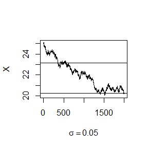

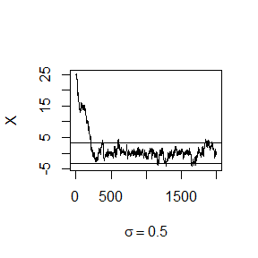

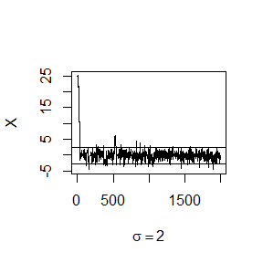

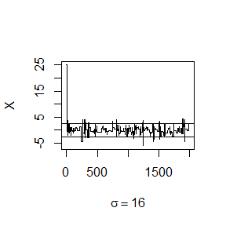

```r
a <- c(.025, .975)
rw <- cbind(rw1$x, rw2$x, rw3$x, rw4$x)
mc <- rw[501:N, ]
Qrw <- apply(mc, 2, function(x) quantile(x, a))

# par(mfrow=c(2,2))  #display 4 graphs together
rw <- cbind(rw1$x, rw2$x, rw3$x,  rw4$x)
for (j in 1:4) {
  plot(rw[,j], type="l",
       xlab=bquote(sigma == .(round(sigma[j],3))),
       ylab="X", ylim=range(rw[,j]))
  abline(h=Qrw[,j])
}
```

```r
par(mfrow=c(1,1)) #reset to default
```

## Question

For Exercise 9.4, use the Gelman-Rubin method to monitor convergence of the chain, and run the chain until it converges approximately to the target distribution according to $\hat{R} < 1.2$.

## Answer

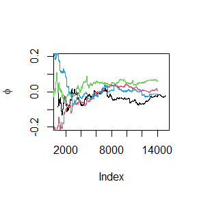

```r
Gelman.Rubin <- function(psi) {
  # psi[i,j] is the statistic psi(X[i,1:j])
  # for chain in i-th row of X
  psi <- as.matrix(psi)
  n <- ncol(psi)
  k <- nrow(psi)

  psi.means <- rowMeans(psi)     #row means
  B <- n * var(psi.means)        #between variance est.
  psi.w <- apply(psi, 1, "var")  #within variances
  W <- mean(psi.w)               #within est.
  v.hat <- W*(n-1)/n + (B/n)     #upper variance est.
  r.hat <- v.hat / W             #G-R statistic
  return(r.hat)
}

Laplace.chain <- function(sigma, N, X1) {
  x <- rep(0, N)
  x[1] <- X1
  u <- runif(N)

  for (i in 2:N) {
    y <- rnorm(1, x[i-1], sigma)
    if (u[i] <= (exp(-abs(y))/2) / (exp(-abs(x[i-1]))/2))
      x[i] <- y else x[i] <- x[i-1]
  }
  return(x)
}

sigma <- 1     #parameter of proposal distribution
k <- 4          #number of chains to generate
n <- 15000      #length of chains
b <- 1000       #burn-in length

#choose overdispersed initial values
x0 <- c(-10, -5, 5, 10)

#generate the chains
set.seed(12345)
X <- matrix(0, nrow=k, ncol=n)
for (i in 1:k)
  X[i, ] <- Laplace.chain(sigma, n, x0[i])

#compute diagnostic statistics
psi <- t(apply(X, 1, cumsum))
for (i in 1:nrow(psi))
  psi[i,] <- psi[i,] / (1:ncol(psi))

#plot psi for the four chains
#    par(mfrow=c(2,2))
for (i in 1:k)
  if(i==1){
    plot((b+1):n,psi[i, (b+1):n],ylim=c(-0.2,0.2), type="l",
         xlab='Index', ylab=bquote(phi))
  }else{
    lines(psi[i, (b+1):n], col=i)
  }
```

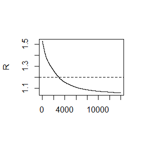

```r
par(mfrow=c(1,1)) #restore default


#plot the sequence of R-hat statistics
rhat <- rep(0, n)
for (j in (b+1):n)
  rhat[j] <- Gelman.Rubin(psi[,1:j])
plot(rhat[(b+1):n], type="l", xlab="", ylab="R")
abline(h=1.2, lty=2)
```

## Question

11.4 Find the intersection points $A(k)$ in $(0,\sqrt{k})$ of the curves
$$S_{k-1}(a)=P \left( t(k-1)>\sqrt{\frac{a^2(k-1)}{k-a^2}} \right)$$
and
$$S_k(a)=P \left( t(k)>\sqrt{\frac{a^2k}{k+1-a^2}} \right),$$

for $k = 4 : 25, 100, 500, 1000,$ where $t(k)$ is a Student t random variable with $k$ degrees of freedom. (These intersection points determine the critical values for a t-test for scale-mixture errors proposed by Sz´ekely [260].)

## Answer

```r
kopt <- c(4:25,100,500,1000)
Ak <- numeric()
set.seed(12345)
for(i in 1:length(kopt)){
  k <- kopt[i]
  f <- function(a) pt(sqrt(a^2*(k-1)/(k-a^2)),df=k-1)-pt(sqrt(a^2*k/(k+1-a^2)),df=k)
  res <- uniroot(f,c(0,sqrt(k))-1e-10,maxiter = 1e6)
  res <- as.numeric(unlist(res)[1])
  if(res>0 & res<sqrt(k)) Ak[i] <- res else Ak[i] <- NA
}
matrix(Ak,ncol=1,dimnames = list(paste("k=",kopt,sep=""),"A(k)"))
```

```
##             A(k)
## k=4     1.492103
## k=5     1.533549
## k=6     1.562768
## k=7     1.584421
## k=8     1.601182
## k=9     1.614517
## k=10    1.625356
## k=11    1.634398
## k=12    1.642026
## k=13    1.648543
## k=14    1.654174
## k=15    1.659100
## k=16    1.663458
## k=17    1.667292
## k=18    1.670738
## k=19    1.673818
## k=20    1.676623
## k=21    1.679137
## k=22    1.681461
## k=23    4.795832
## k=24    4.898979
## k=25    5.000000
## k=100  10.000000
## k=500  22.360680
## k=1000        NA
```

# HW8 (2020.11.24)

## Question

A-B-O blood type problem

## Answer

```r
EL <- function(pq)
  -(((po^2/(po^2+2*po*(1-po-qo))+1)*nA.+nAB)*log(pq[1])+
   ((qo^2/(qo^2+2*qo*(1-po-qo))+1)*nB.+nAB)*log(pq[2])+
   ((1-po^2/(po^2+2*po*(1-po-qo)))*nA.+(1-qo^2/(qo^2+2*qo*(1-po-qo)))*nB.+2*nOO)*log(1-sum(pq)))

nA.<-444;nB.<-132;nOO<-361;nAB<-63
iter <- 20
po <- qo <- 0.2
iter.result <- matrix(nrow=iter+1,ncol=2,
                      dimnames=list(c("initial",paste("iteration",1:iter,sep="")),c("p","q")))
logml <- numeric()
iter.result[1,] <- c(po,qo)
logml[1] <- -EL(c(po,qo))

for(i in 1:iter){
  if(i>1) {po <- iter.result[i-1,1]; qo <- iter.result[i-1,2]}
  em <- optim(c(po,qo), EL)
  iter.result[i+1,] <- em$par
  logml[i+1] <- -em$value
}
cbind(iter.result,logml)
```

```
##                     p         q     logml
## initial     0.2000000 0.2000000 -1883.277
## iteration1  0.2851792 0.1069312 -1798.910
## iteration2  0.2851792 0.1069312 -1798.910
## iteration3  0.2956437 0.1029142 -1799.918
## iteration4  0.2956437 0.1029142 -1799.918
## iteration5  0.2972700 0.1026838 -1801.731
## iteration6  0.2972700 0.1026838 -1801.731
## iteration7  0.2975482 0.1027006 -1802.118
## iteration8  0.2975482 0.1027006 -1802.118
## iteration9  0.2976535 0.1026963 -1802.200
## iteration10 0.2976535 0.1026963 -1802.200
## iteration11 0.2976535 0.1026963 -1802.228
## iteration12 0.2976535 0.1026963 -1802.228
## iteration13 0.2976535 0.1026963 -1802.228
## iteration14 0.2976535 0.1026963 -1802.228
## iteration15 0.2976535 0.1026963 -1802.228
## iteration16 0.2976535 0.1026963 -1802.228
## iteration17 0.2976535 0.1026963 -1802.228
## iteration18 0.2976535 0.1026963 -1802.228
## iteration19 0.2976535 0.1026963 -1802.228
## iteration20 0.2976535 0.1026963 -1802.228
```

## Question

Use both for loops and lapply() to fit linear models to the mtcars using the formulas stored in this list:  
formulas <- list(  
mpg ~ disp,  
mpg ~ I(1 / disp),  
mpg ~ disp + wt,  
mpg ~ I(1 / disp) + wt  
)

## Answer

```r
formulas <- list(
  mpg ~ disp,
  mpg ~ I(1 / disp),
  mpg ~ disp + wt,
  mpg ~ I(1 / disp) + wt
)

# loops
n <- length(formulas)
result <- list()
for(i in 1:n) result[[i]] <- lm(formulas[[i]], data = mtcars)
result
```

```
## [[1]]
##
## Call:
## lm(formula = formulas[[i]], data = mtcars)
##
## Coefficients:
## (Intercept)         disp
##    29.59985     -0.04122
##
##
## [[2]]
##
## Call:
## lm(formula = formulas[[i]], data = mtcars)
##
## Coefficients:
## (Intercept)    I(1/disp)
##       10.75      1557.67
##
##
## [[3]]
##
## Call:
## lm(formula = formulas[[i]], data = mtcars)
##
## Coefficients:
## (Intercept)         disp           wt
##    34.96055     -0.01772     -3.35083
##
##
## [[4]]
##
## Call:
## lm(formula = formulas[[i]], data = mtcars)
##
## Coefficients:
## (Intercept)    I(1/disp)           wt
##      19.024     1142.560       -1.798
```

```r
# lapply
lapply(formulas, lm, data = mtcars)
```

```
## [[1]]
##
## Call:
## FUN(formula = X[[i]], data = ..1)
##
## Coefficients:
## (Intercept)         disp
##    29.59985     -0.04122
##
##
## [[2]]
##
## Call:
## FUN(formula = X[[i]], data = ..1)
##
## Coefficients:
## (Intercept)    I(1/disp)
##       10.75      1557.67
##
##
## [[3]]
##
## Call:
## FUN(formula = X[[i]], data = ..1)
##
## Coefficients:
## (Intercept)         disp           wt
##    34.96055     -0.01772     -3.35083
##
##
## [[4]]
##
## Call:
## FUN(formula = X[[i]], data = ..1)
##
## Coefficients:
## (Intercept)    I(1/disp)           wt
##      19.024     1142.560       -1.798
```

## Question

The following code simulates the performance of a t-test for non-normal data. Use sapply() and an anonymous function to extract the p-value from every trial.  
trials <- replicate(  
100,  
t.test(rpois(10, 10), rpois(7, 10)),  
simplify = FALSE  
)  
Extra challenge: get rid of the anonymous function by using [[ directly.

## Answer

```r
trials <- replicate(
  100,
  t.test(rpois(10, 10), rpois(7, 10)),
  simplify = FALSE
)
sapply(trials,function(x) x$p.value)
```

```
##   [1] 0.178809502 0.994262402 0.064786264 0.952716251 0.306702525 0.198224877
##   [7] 0.272315768 0.283722503 0.415010770 0.151957272 0.072625558 0.249014108
##  [13] 0.773938569 0.225693023 0.840328179 0.987492066 0.316112244 0.481740992
##  [19] 0.457889571 0.565871989 0.990401857 0.257905112 0.538178810 0.764364559
##  [25] 0.845551784 0.905726387 0.086725138 0.763639767 0.088857796 0.531422351
##  [31] 0.731524606 0.195574176 0.598923896 0.702134266 0.147168770 0.552598436
##  [37] 0.117002585 0.233188724 0.127240002 0.115791872 0.317030411 0.691674119
##  [43] 0.450514119 0.315343567 0.073583503 1.000000000 0.011099981 0.580714657
##  [49] 0.591841839 0.638287091 0.283349660 0.722557025 0.408819857 0.127117578
##  [55] 0.000507563 0.841418067 0.624022112 0.650656602 0.632088219 0.578419158
##  [61] 0.052008307 0.920025002 0.646534041 0.344836350 0.751638828 0.687324041
##  [67] 0.134492519 0.490444844 0.711864108 0.020394691 0.342792908 0.960823950
##  [73] 0.111337525 0.546907007 0.773231299 0.626303636 0.298304108 0.146218612
##  [79] 0.133931753 0.814393484 0.096839576 0.974929586 0.808056754 0.346709412
##  [85] 0.308443909 0.600935588 0.984471134 0.703069949 0.678262994 0.565803030
##  [91] 0.895621651 0.723438333 0.431024548 0.061331285 0.043636182 0.359298038
##  [97] 0.372409666 0.953012247 0.503028465 0.594358009
```

## Question

Implement a combination of Map() and vapply() to create an lapply() variant that iterates in parallel over all of its inputs and stores its outputs in a vector (or a matrix). What arguments should the function take?

## Answer

```r
f <- function(data,fun,FUN.VALUE){
  data2 <- Map(fun,data)
  vapply(data2,function(x) x,FUN.VALUE)
}

FUN.VALUE <- double(1)
fun <- mean
data <- data.frame(replicate(6,sample(c(1:10),10,rep=T)))
f(data,fun,FUN.VALUE)
```

```
##  X1  X2  X3  X4  X5  X6
## 6.1 5.1 5.6 4.3 4.9 5.3
```

The arguments that the function should take includes data, analysis function and the type of output.

# HW9 (2020.12.01)

## Question

Exercise 9.4: Implement a random walk Metropolis sampler for generating the standard Laplace distribution (see Exercise 3.2). For the increment, simulate from a normal distribution. Compare the chains generated when different variances are used for the proposal distribution. Also, compute the acceptance rates of each chain.

## Question

Write an Rcpp function for Exercise 9.4.

## Answer

```cpp
#include <cmath>
#include <Rcpp.h>
using namespace Rcpp;
double lap_f(double x){
  double y = exp(-fabs(x));
  return y;
}
// [[Rcpp::export]]
NumericVector CrwM(double sigma, double x0, int N){
  NumericVector x(N);
  NumericVector u = runif(N);
  x[0] = x0;


  for (int i = 1; i < N; ++i) {
    NumericVector z = rnorm(1, x[i-1], sigma);
    if (u[i] <= (lap_f(z[0]) / lap_f(x[(i-1)]))) {
      x[i] = z[0];
    } else {
      x[i] = x[(i-1)];
    }
  }

  return x;
}
```

## Question

Compare the corresponding generated random numbers with those by the R function you wrote before using the function “qqplot”.

## Answer

```r
library(Rcpp)
```

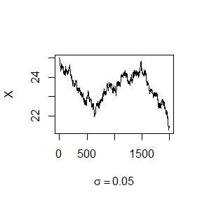

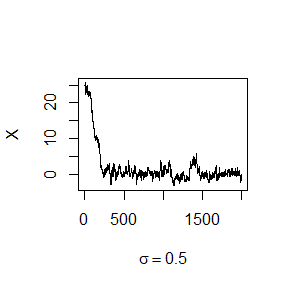

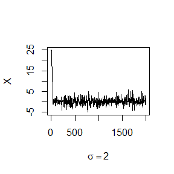

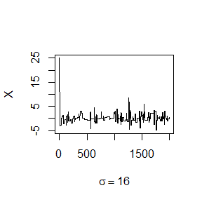

```r
# sourceCpp("CMetro.cpp")

set.seed(3000)

lap_f = function(x) exp(-abs(x))

RrwM = function(sigma, x0, N){
  x = numeric(N)
  x[1] = x0
  u = runif(N)
  k = 0
  for (i in 2:N) {
    y = rnorm(1, x[i-1], sigma)
    if (u[i] <= (lap_f(y) / lap_f(x[i-1]))) x[i] = y
    else {
      x[i] = x[i-1]
      k = k+1
    }
  }
  return(list(x = x, k = k))
}

N = 2000
sigma = c(.05, .5, 2, 16)
x0 = 25
crw = list()
rrw = list()
for(i in 1:length(sigma)){
  crw[[i]] = CrwM(sigma[i],x0,N)
  rrw[[i]] = RrwM(sigma[i],x0,N)
}

# R function
# par(mfrow=c(2,2))
for (j in 1:4) {
  plot(rrw[[j]]$x, type="l",
       xlab=bquote(sigma == .(round(sigma[j],3))),
       ylab="X", ylim=range(rrw[[j]]$x))
}
```

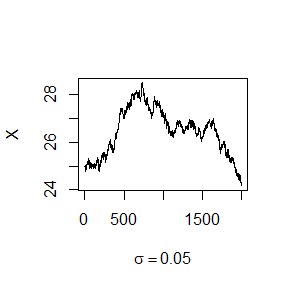

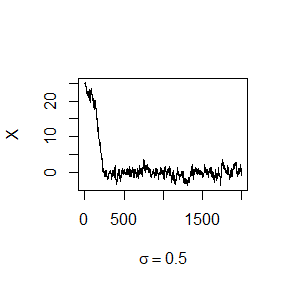

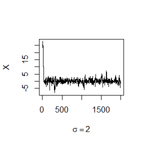

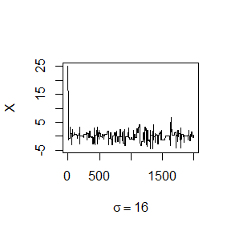

```r
# Rcpp function
# par(mfrow=c(2,2))
for (j in 1:4) {
  plot(crw[[j]], type="l",
       xlab=bquote(sigma == .(round(sigma[j],3))),
       ylab="X", ylim=range(crw[[j]]))
}
```

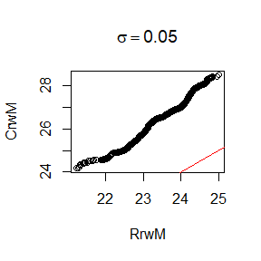

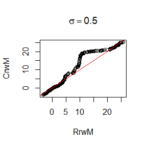

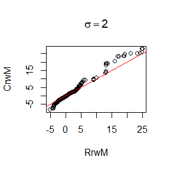

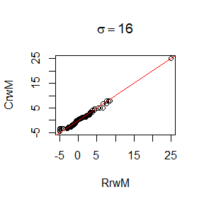

```r
# Q-Q plot
# par(mfrow=c(2,2))
for(i in 1:length(sigma)){
  qqplot(rrw[[i]]$x,crw[[i]],xlab="RrwM",ylab="CrwM",
         main=bquote(sigma == .(round(sigma[i],3))))
  abline(0,1,col="red")
}
```

## Question

Campare the computation time of the two functions with the function “microbenchmark”.

## Answer

```r
library(microbenchmark)
microbenchmark(rwR=RrwM(sigma[1],x0,N),rwC=CrwM(sigma[1],x0,N))
```

```
## Unit: microseconds
##  expr    min      lq      mean   median       uq     max neval
##   rwR 8914.3 16489.7 21807.948 20332.45 24408.50 77209.2   100
##   rwC  411.1   589.2   854.883   719.00   797.15 11489.3   100
```

## Question

Comments your results.

## Answer

From Q-Q plot, we can see that when the standard variance of increment is large, the distribution of the corresponding random numbers generated by R function and Rcpp function are similar because most of the points are located near the diagonal. However, when the standard variance is small, like the first two figures, the difference of two distribution is large.  
For computation time, Rcpp function has obvious advantages compared to R function because it needs less computation time.